# MBAn556_HW1

#### Silhouette Method

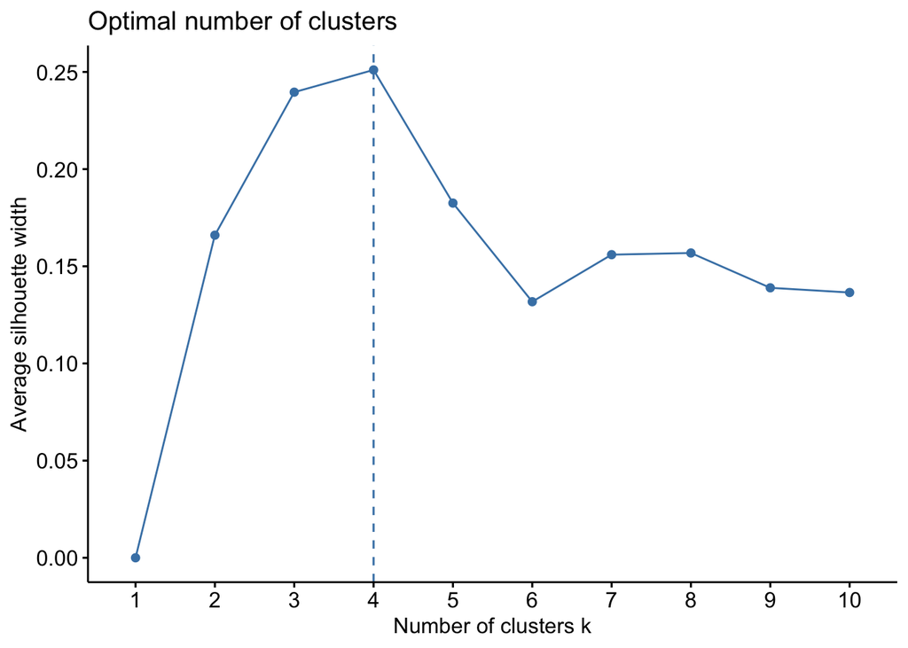

```r
#optimal # of clusters using Silhouette
fviz_nbclust(wine_data, kmeans, method = "silhouette")
```

```r
#indicates 4 clusters are otimal
```

#### WSS Method

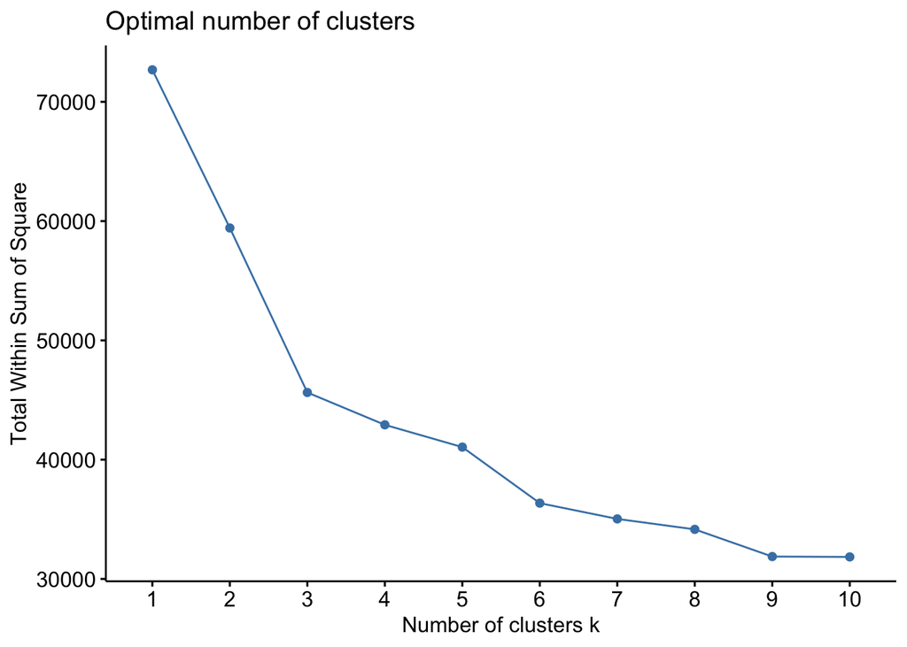

```r
#optimal number of clusters usimg WSS method
fviz_nbclust(wine_data, kmeans, method = "wss")
```

```r
#indicates 3 or 4 clusters are optimal
```

### Create and Visualize clusters

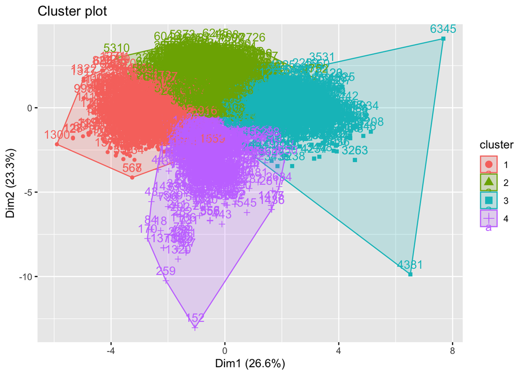

```r
#initially set seed of 112345, but noticed that the randomized clusters of that see were less homogeneous, so switched it to 13579.
set.seed(13579)
km_1 <- kmeans(wine_data, 4)

wine_data$cluster <- km_1$cluster
fviz_cluster(km_1, data= wine_data)
```

```r
# We can clearly see four distinct regions of the plot, however, not all are homogeneous. This may indicate the the four main types of wine may share overlapping qualities with other types. However, this heterogeneity is less than it was with seed 1-5.
```

Visualize Via ellipses

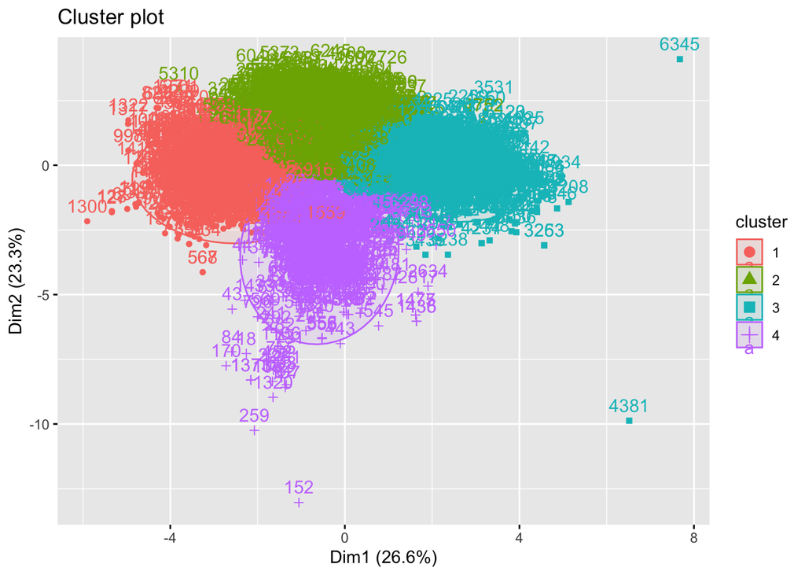

```r
fviz_cluster(km_1, data = wine_data, ellipse = TRUE, ellipse.type = "norm", ellipse.level = .95, ellipse.alpha = .1)
```

```r
#visualization with ellipses is nearly identical, we still see some heterogeneity, and lack of dispersion between the clusters.
```

# Visualize Cluster Variables

You decided that although you have visualized your clusters, you also want to visualize the metrics within them, to better understand your collection, and the qualities within each cluster.

```r
library(reshape2)
```

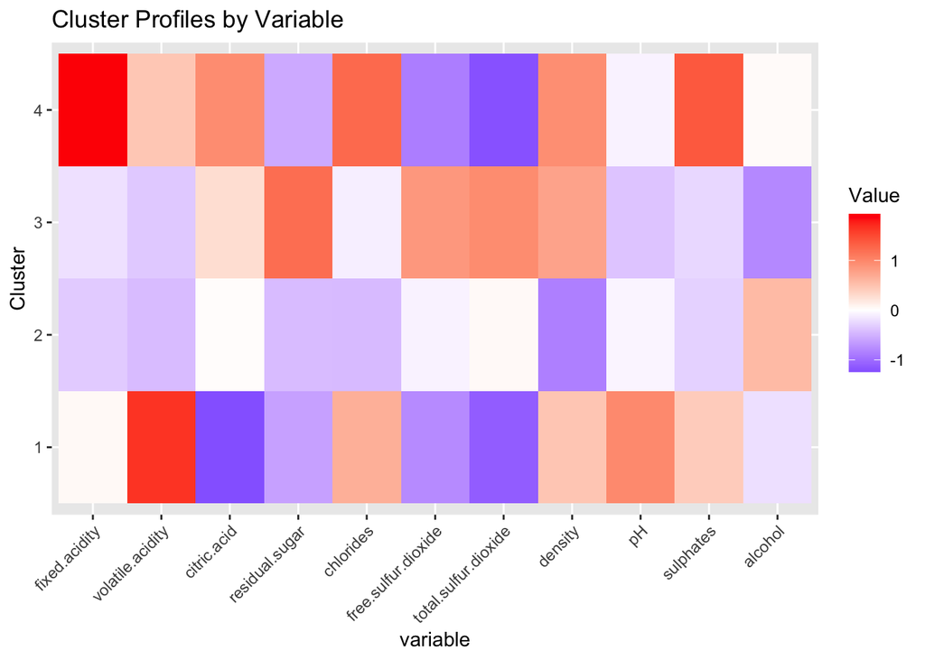

```r
library(ggplot2)

centroids <- aggregate(. ~ cluster, data = wine_data, FUN = mean)
centroids_melt <- melt(centroids, id.vars = "cluster")

ggplot(centroids_melt, aes(x=variable, y=factor(cluster), fill=value)) +
  geom_tile() +
  scale_fill_gradient2(low="blue", mid="white", high="red", midpoint=0) +
  theme(axis.text.x = element_text(angle=45, hjust=1)) +
  labs(title="Cluster Profiles by Variable", y="Cluster", fill="Value")
```

### Total Results:

#### Cluster 1:

This cluster is characterized by: - high positive values of volatile acidity - mild positive values of chlorides, density, PH, and sulfate - mild negative values of fixed acidity, alcohol quantity, sugar, and free sulfur dioxide - high negative values of citric acid and total sulfur dioxide

Result 1: Cluster 1 is mostly composed of red wines that are dry, tart, and lightly bodied, with higher volatile acidity and lower sugar and citric acid. These characteristics are more typical of red wines than whites.

#### Cluster 2:

This cluster is characterized by: -high positive values of nothing - mild positive values of alcohol - mild negative values of fixed acidity, volatile acidity, residual sugar, chlorides, and sulfates - high negative values of density

Result 2: Cluster 2 is mostly composed of white wines that are light-bodied, dry, and balanced, with slightly higher alcohol and lower acidity, sugar, and density compared to other clusters. These wines are likely easy-drinking and neutral in flavor, such as Sauvignon Blanc or Chardonnay.

#### Cluster 3:

This cluster is characterized by: -high positive values of residual sugar - mild positive values of free sulfur dioxide, total sulfur dioxide, and density - mild negative values of fixed acidity, volatile acidity, PH - high negative values of alcohol

Result 3: Cluster 3 is mostly composed of white wines that are sweet, low in alcohol, and slightly fuller-bodied, with lower acidity and pH. These wines are likely dessert-style or late-harvest wines with noticeable sugar content, such as moscato or pinot grigio.

#### Cluster 4:

This cluster is characterized by: -high positive values of fixed acidity, sulphates & chlorides - mild positive values of citric acid, density - mild negative values of free sulfur dioxide, residual sugar - high negative values of total sulfur dioxide

Result 4: Likely red type. Probably a more medium-bodied, dry, tangy red wines (like a lighter red blend or Pinot Noir, not heavy Cabernet-style reds)

# View PCA’s

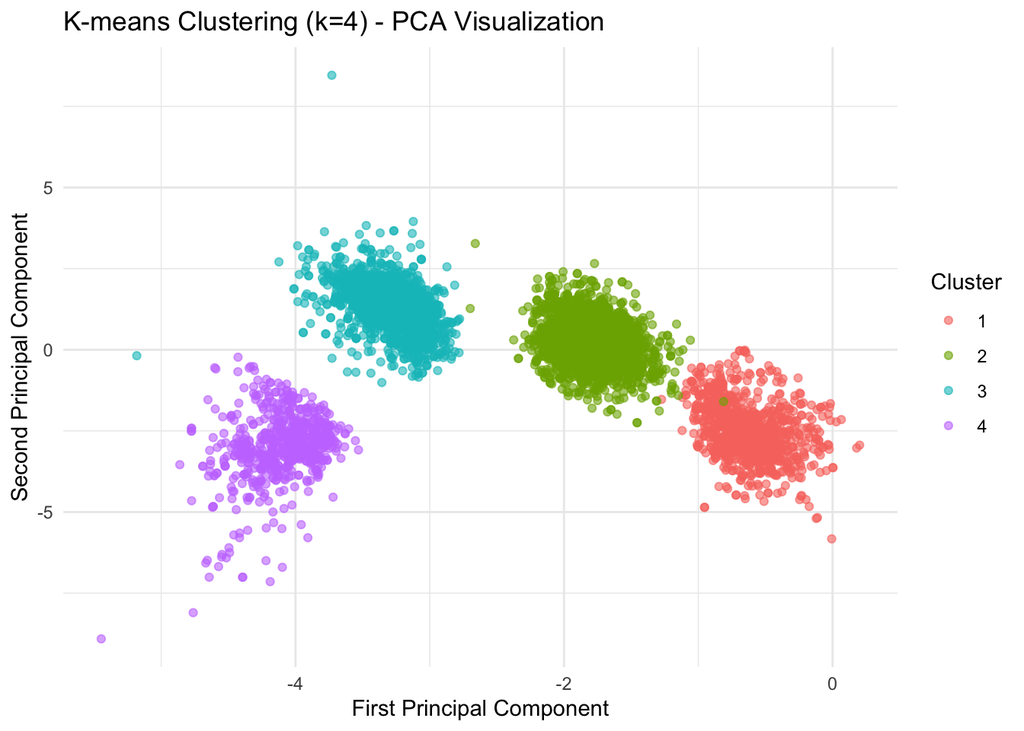

```r
# PCA on your scaled features
pca <- prcomp(wine_data, center = FALSE, scale. = FALSE)

# Create dataframe with PCA results
pca_df <- as.data.frame(pca$x[, 1:2])
pca_df$Cluster <- as.factor(km_1$cluster)
pca_df$type <- winedata$type
pca_df$quality <- winedata$quality

# Visualize the clusters
library(ggplot2)
ggplot(pca_df, aes(x = PC1, y = PC2, color = Cluster)) +
  geom_point(alpha = 0.6) +
  labs(title = "K-means Clustering (k=4) - PCA Visualization",
       x = "First Principal Component",
       y = "Second Principal Component") +
  theme_minimal()
```

Result: We can clearly see 4 distinct PCA’s! The separation between clusters in the two-dimensional PCA space confirms that the k-means algorithm identified meaningful groupings based on chemical properties.

# Predicitive Model

## Decision Tree

Considering the goal of this project is to accurately predict wines into categories, you want to test you clusters & their predictive abilities via two ways, and you just remembered you took a predictive analytics course!

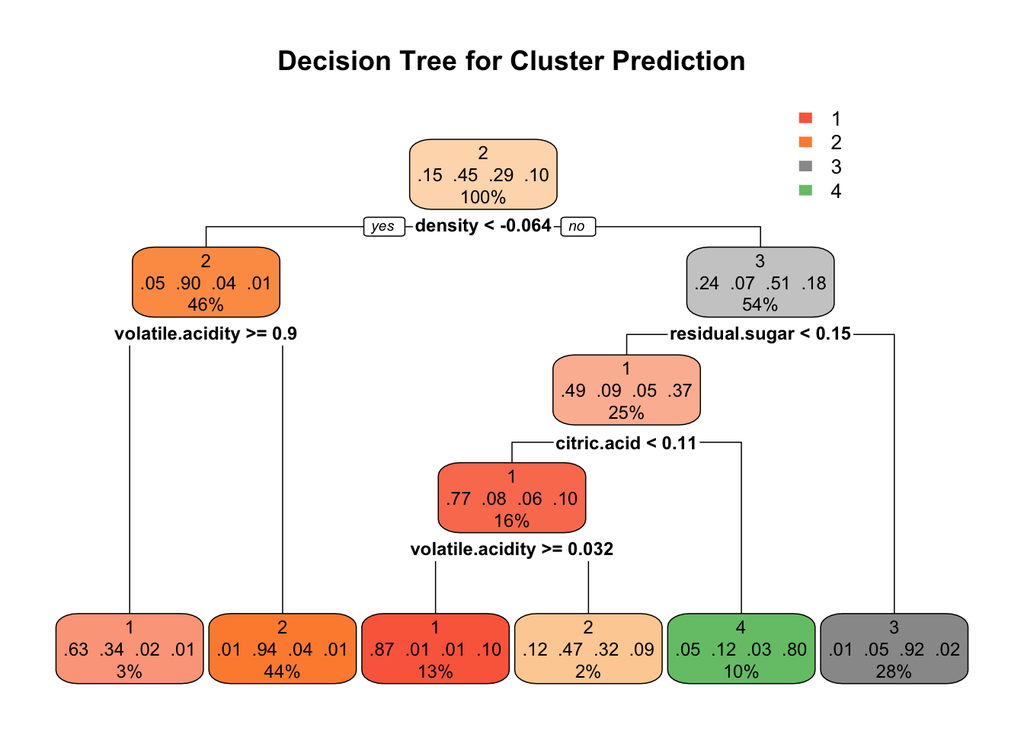

```r
library(rpart)
library(rpart.plot)
# Create model: predict Type using all other variables
# Train tree to predict clusters
tree_model <- rpart(cluster ~ ., data = wine_data, method = "class")

# Visualize the tree
rpart.plot(tree_model, main = "Decision Tree for Cluster Prediction")
```

### See if the decision tree displays internal vaidation

```r
# Predict clusters on the training data
pred_tree <- predict(tree_model, wine_data, type = "class")

# Confusion matrix to check accuracy
confusionMatrix(pred_tree, as.factor(wine_data$cluster))
```

```
## Confusion Matrix and Statistics
##
##           Reference
## Prediction    1    2    3    4
##          1  881   73   14   92
##          2   50 2716  155   53
##          3   25   90 1683   34
##          4   31   77   20  503
##
## Overall Statistics
##
##                Accuracy : 0.8901
##                  95% CI : (0.8822, 0.8976)
##     No Information Rate : 0.455
##     P-Value [Acc > NIR] : < 2.2e-16
##
##                   Kappa : 0.8373
##
##  Mcnemar's Test P-Value : 1.124e-11
##
## Statistics by Class:
##
##                      Class: 1 Class: 2 Class: 3 Class: 4
## Sensitivity            0.8926   0.9188   0.8990  0.73754
## Specificity            0.9675   0.9271   0.9678  0.97799
## Pos Pred Value         0.8311   0.9132   0.9187  0.79715
## Neg Pred Value         0.9805   0.9319   0.9595  0.96949
## Prevalence             0.1519   0.4550   0.2881  0.10497
## Detection Rate         0.1356   0.4180   0.2590  0.07742
## Detection Prevalence   0.1632   0.4577   0.2820  0.09712
## Balanced Accuracy      0.9301   0.9230   0.9334  0.85776
```

Intrernal Validation Continued:

Example for variable 100 in data set:

```r
#real variable, X = 100
X100_wine <- data.frame(
  fixed.acidity = 0.68240504,
  volatile.acidity = 1.247196294,
  citric.acid = -0.95399981,
  residual.sugar = -0.74472079,
  chlorides = 0.6840901,
  free.sulfur.dioxide =-0.98737533 ,
  total.sulfur.dioxide = -1.42855494,
  density = 0.8348247,
  pH = 0.506875873,
  sulphates = 0.394686855,
  alcohol = -1.250763927
)
#Expected Result: Cluster 1
predict(tree_model, X100_wine, type = "class")
```

```
## 1
## 1
## Levels: 1 2 3 4
```

```r
#result was accurate: Cluster 1
```

## Distance to Center Cluster

Each cluster assignments in the dataset are already the result of the distance-from-center method. Each wine was assigned to its cluster based on which cluster center it was nearest to in the multi-dimensional feature space.So no need to hard code, as seen in the example with X=100, below.

Since the dataset only contains two true wine categories (red and white), a traditional 4x4 confusion matrix cannot be created. Instead, I evaluated the predictive ability of the 4-cluster solution by mapping each cluster to its majority wine type (red or white), then assessing how accurately these cluster-based predictions matched the actual wine colors. This approach allows us to determine whether the distance-based clustering method successfully captures the fundamental red/white distinction in the data.

```r
#try new
winedata$cluster <- km_1$cluster

# Map each cluster to its majority wine type
map_type <- winedata %>%
  group_by(cluster) %>%
  summarise(majority_type = names(which.max(table(type))), .groups = "drop")

# Predict type based on cluster
pred_type <- winedata %>%
  left_join(map_type, by = "cluster") %>%
  transmute(Predicted = majority_type, True = type)

# Confusion matrix
library(caret)
confusionMatrix(factor(pred_type$Predicted), factor(pred_type$True))
```

```
## Confusion Matrix and Statistics
##
##           Reference
## Prediction  red white
##      red   1563   106
##      white   36  4792
##
##                Accuracy : 0.9781
##                  95% CI : (0.9743, 0.9816)
##     No Information Rate : 0.7539
##     P-Value [Acc > NIR] : < 2.2e-16
##
##                   Kappa : 0.942
##
##  Mcnemar's Test P-Value : 7.024e-09
##
##             Sensitivity : 0.9775
##             Specificity : 0.9784
##          Pos Pred Value : 0.9365
##          Neg Pred Value : 0.9925
##              Prevalence : 0.2461
##          Detection Rate : 0.2406
##    Detection Prevalence : 0.2569
##       Balanced Accuracy : 0.9779
##
##        'Positive' Class : red
##
```

Results: The distance-based clustering method performed exceptionally well at predicting wine type, achieving 97.8% accuracy. Only 142 wines were incorrectly classified out of 6,497 total (106 white wines misclassified as red, 36 red wines misclassified as white)

Example with X = 100

```r
distances <- apply(km_1$centers, 1, function(center) {
  sqrt(sum((as.numeric(X100_wine) - center)^2))
})
closest_cluster <- which.min(distances)
closest_cluster
```

```
## 1
## 1
```

```r
#Result: closest cluster is once again 1: Correct!
```

# Final Descrition of Cluster Characterizations

```r
# four clusters are optimal: so create final km
set.seed(13579)
km_1 <- kmeans(wine_data, 4)
wine_data$cluster <- as.factor(km_1$cluster)

# 4 clusters
winedata %>%
  group_by(cluster) %>%
  summarise(
    n = n(),
    avg_alcohol = mean(alcohol),
    avg_sugar = mean(residual.sugar),
    prop_red = mean(type == "red")
  )
```

```
## # A tibble: 4 × 5
##   cluster     n avg_alcohol avg_sugar prop_red
##     <int> <int>       <dbl>     <dbl>    <dbl>
## 1       1   987       10.2       2.50  0.932
## 2       2  2956       11.2       3.38  0.0108
## 3       3  1872        9.54     11.2   0.00214
## 4       4   682       10.5       2.77  0.943
```

# Compare the two methods

Between the desicion tree method, and the distance from center method, distance from center yielded the highest accuracy in correctly classifying wines! This may be because the distance-based method considers all chemical properties together when calculating similarity, capturing complex interactions between variables. Decision trees, by contrast, make sequential splits on individual features, potentially missing important multivariate patterns.

# Conclusion

As the newly appointed Wine Connoisseur at Blythefield Country Club, the goal was to develop a data-driven approach to understanding and classifying the club’s wine collection without relying on subjective tasting notes or specialized wine vocabulary. Through exploratory data analysis and clustering techniques, this project successfully identified patterns in the chemical properties that distinguish different wines.

Key Findings:

The analysis revealed that k-means clustering with 4 clusters effectively organized the wine collection based on chemical similarity. Most importantly, when evaluating the predictive power of these clusters, the distance-from-center method achieved an impressive 97.8% accuracy in distinguishing red wines from white wines. Also noteworthy, the decision tree model yielded an accuracy of 89%!

Armed with these insights, wine recommendations at Blythefield Country Club can now be made with confidence and precision. When a member requests a wine similar to one they enjoyed, the clustering model can instantly identify chemically similar wines from the same cluster.

Thank you!!